# Capstone-4

**Bibliotheca E-Book Subscription Recommendation**

# Group Members

**Gokul Prakash Babu** **Gomathi Sornaganesh** **Gourav Kumar** **Grace Kollabathula** **Gudla Sabarish**

# Task 2.4 Model building using ML algorithms

```python
import numpy as np
import pandas as pd
import matplotlib.pyplot as plt
import seaborn as sns
pd.set_option('display.max_colwidth',None)
pd.options.display.max_rows=99999
```

# Insering data from csv files to pandas dataframes

```python
bookm = pd.read_csv("BOOKSMASTERTRAIN.csv")
user = pd.read_csv("USERMASTER.csv")
bookcat=pd.read_csv("BOOKSCATALOGUE.csv")
bookph = pd.read_csv("BOOKSPURCHHISTORY.csv")
bookvh =  pd.read_csv("BOOKSVISITHISTORY.csv")
bookss = pd.read_csv("SAMPLESUBMISSION.csv")
```

```python
bookm.columns
```

```
Index(['BookID', 'GENRE', 'BOOKTITLE', 'BOOKNAME', 'SERIES', 'AUTHOR',
       'USERRATINGS', 'OTHERPRINTEDINFO', 'DETAILS', 'SUMMARY', 'GENRE.1',
       'AUTHORDESC', 'COVERPAGE', 'Popularity'],
      dtype='object')
```

```python
# Top 10 Highest rated books
bk=bookm.copy()
bk.sort_values(by='USERRATINGS',ascending=False,inplace=True)
bk['SERIES'].fillna(" ",inplace=True)
bk['BOOK']= bk['BOOKNAME']+bk['SERIES']
bk["BOOK"].head()
```

```
383                         Love That Moves the Sun: Vittoria Colonna and Michaelangelo Buonarroti
1392                                                            Doctors in Hell(Heroes in Hell #18)
1474    The China-America Alliance: East Asian and American Cultural Values Promote Global Harmony
819                                                      Harry Potter Collection(Harry Potter #1-6)
947                                                      Harry Potter Collection(Harry Potter #1-6)
Name: BOOK, dtype: object
```

Maping the users with their purchased books using book purchase history

```python
bookph['TIMESTAMP'] =pd.to_datetime(bookph['TIMESTAMP'])
bookph.sort_values(by="TIMESTAMP",ascending=False,inplace=True)
df = bookph[['UserID','BookID']]
d= df.groupby("UserID").groups
s = pd.DataFrame({"USERID":d.keys()})
s['INDEX']= [list(d[x]) for x in d.keys()]
```

```python
p=[]
for x in s["INDEX"].values:
    k=list(map(lambda y:bookph.loc[y,"BookID"],x))
    p.append(k)
s['BOOKS']=p
s.drop('INDEX',axis=1,inplace=True)
```

Maping the users in samplesubmission file to purchased books for giving recomendations

```python
sample=pd.merge(bookss,s,on="USERID",how='left')
sample.drop('PURCHASEDBOOKID',axis=1,inplace=True)
sample["BOOKS"].fillna("",inplace=True)
sample.head()
```

|  | USERID | BOOKS |
| --- | --- | --- |
| 0 | 600003 |  |
| 1 | 600008 | [165498] |
| 2 | 600011 | [162488, 155019] |
| 3 | 600017 | [121582, 135346] |
| 4 | 600020 | [114845, 169328, 165478, 132243, 121906, 105481, 154892, 114400, 117578, 109177, 117564, 167437] |

```python
user.describe()
print(bookph["BookID"].size)
print(bookph["BookID"].unique().size)
print(bookph["UserID"].unique().size)
```

```
43072
3510
10877
```

selecting the appropriate columns for analysis

```python
bookm =bookm.get(['BookID','GENRE','BOOKNAME','SERIES','USERRATINGS'])
bookm["SERIES"].fillna("",inplace=True)
bookm.head()
```

|  | BookID | GENRE | BOOKNAME | SERIES | USERRATINGS |
| --- | --- | --- | --- | --- | --- |
| 0 | 114530 | Fiction | The Curious Incident of the Dog in the Night-Time |  | 3.87 |
| 1 | 133131 | Science Fiction | Rainbows End |  | 3.76 |
| 2 | 153927 | Nonfiction | See No Evil: The True Story of a Ground Soldier in the CIA's War on Terrorism |  | 3.93 |
| 3 | 160262 | History | Augustus: The Life of Rome's First Emperor |  | 4.03 |
| 4 | 133451 | Mystery | An Unquiet Grave | (Louis Kincaid #7) | 4.12 |

concatenating the book name with the series name

```python
bookm["Book"] = bookm["BOOKNAME"]+bookm["SERIES"]
bookm.drop(columns=['BOOKNAME','SERIES'],inplace=True)
```

Removing the data for the books which are purchased by same user multiple times

```python
bookph = bookph.get(['UserID','BookID'])
bookph.drop_duplicates(inplace=True)
```

Maping the users with the number of books puchased

```python
bookpur = pd.DataFrame(bookph.groupby('UserID')['BookID'].count().reset_index())
bookpur.rename(columns={"BookID":"No_Of_Books_Purchased"},inplace=True)
print(bookpur.shape)
print(bookpur[bookpur["No_Of_Books_Purchased"]==1].shape)
print(bookpur[bookpur["No_Of_Books_Purchased"]<3].shape)
print(bookpur[bookpur["No_Of_Books_Purchased"]>=3].shape)
```

```
(10877, 2)
(4365, 2)
(6310, 2)
(4567, 2)
```

Histogram of number of books purchased

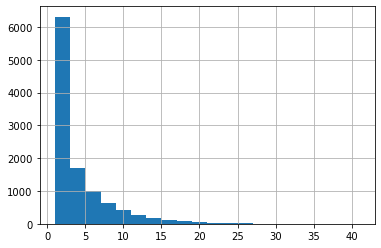

```python
bookpur["No_Of_Books_Purchased"].hist(bins=20)
```

Selecting the users who have purchased more than 2 books on the basis of mean of number of books purchased

```python
bookpur= bookpur[bookpur["No_Of_Books_Purchased"]>=3]
x= bookpur["UserID"]
bookph = bookph[bookph["UserID"].isin(x)]
bookph.shape
```

```
(32188, 2)
```

Merging the user information

```python
da = pd.merge(bookph,user,on="UserID",how ="left")
df=da.get(['UserID','BookID','AGEGROUP','GENDER'])
df.shape
```

```
(32188, 4)
```

Maping the bookids with the bookname and user ratings

```python
fin = pd.merge(df,bookm,on = "BookID",how = "left")
fin.columns
fin.info()
```

```
<class 'pandas.core.frame.DataFrame'>
Int64Index: 32188 entries, 0 to 32187
Data columns (total 7 columns):
 #   Column       Non-Null Count  Dtype
---  ------       --------------  -----
 0   UserID       32188 non-null  int64
 1   BookID       32188 non-null  int64
 2   AGEGROUP     32188 non-null  float64
 3   GENDER       32188 non-null  object
 4   GENRE        14048 non-null  object
 5   USERRATINGS  14048 non-null  float64
 6   Book         14048 non-null  object
dtypes: float64(2), int64(2), object(3)
memory usage: 2.0+ MB
```

Deleting the records whose book information is not available in bookmastertrain file

```python
fin.dropna(subset= ['Book'],inplace=True)
fin.info()
```

```
<class 'pandas.core.frame.DataFrame'>
Int64Index: 14048 entries, 5 to 32187
Data columns (total 7 columns):
 #   Column       Non-Null Count  Dtype
---  ------       --------------  -----
 0   UserID       14048 non-null  int64
 1   BookID       14048 non-null  int64
 2   AGEGROUP     14048 non-null  float64
 3   GENDER       14048 non-null  object
 4   GENRE        14048 non-null  object
 5   USERRATINGS  14048 non-null  float64
 6   Book         14048 non-null  object
dtypes: float64(2), int64(2), object(3)
memory usage: 878.0+ KB
```

Getting the info about the number of users bought the book

```python
ratings = fin.groupby('BookID')['USERRATINGS'].count()
rat = pd.DataFrame(ratings.reset_index())
rat.rename(columns={'USERRATINGS':"No_Of_Userratings"},inplace=True)
```

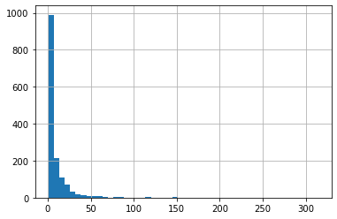

```python
rat["No_Of_Userratings"].hist(bins=50)
```

```python
rat[rat["No_Of_Userratings"]>5].shape
```

```
(624, 2)
```

```python
rat = rat[rat["No_Of_Userratings"]>5]
rat.describe()
```

|  | BookID | No_Of_Userratings |
| --- | --- | --- |
| count | 624.000000 | 624.000000 |
| mean | 141291.179487 | 19.192308 |
| std | 23228.665350 | 23.997422 |
| min | 100080.000000 | 6.000000 |
| 25% | 121610.500000 | 8.000000 |
| 50% | 141462.000000 | 12.000000 |
| 75% | 161333.250000 | 21.000000 |
| max | 179987.000000 | 314.000000 |

```python
findata= pd.merge(fin,rat,on="BookID",how="right")
findata.shape
```

```
(11976, 8)
```

```python
findata.sort_values(by=["USERRATINGS",'No_Of_Userratings'],ascending=False,inplace=True)
```

Creating a list of books with highest userratings and most reviewed

```python
j=0
books=[]
for i in findata['Book'].unique():
    if j<10:
        books.append(i)
    j+=1
```

Pivot matrix

```python
book_pivot = findata.pivot(columns='UserID',index="BookID",values="USERRATINGS")
book_pivot.fillna(0,inplace=True)
book_pivot.shape
```

```
(624, 4067)
```

```python
from scipy.sparse import csr_matrix
book_pred= csr_matrix(book_pivot)
```

```python
from sklearn.neighbors import NearestNeighbors
model_knn = NearestNeighbors(algorithm = 'brute')
model_knn.fit(book_pred)
```

```
NearestNeighbors(algorithm='brute')
```

Function to return bookid based on the user id

```python
def book(user):
    y=0
    user2 =sample[sample['USERID']==user]
    for x in user2.BOOKS.values:
        if len(x)==0:
            return books
        else:
            for i in x:
                if i in findata['BookID'].values:
                    y=i
                    break
            if y==0:
                return books
            else:
                return y
```

Function returns bookname from bookids

```python
def bookname(bookid):
    bk = bookm[bookm["BookID"]==bookid]
    for x in bk.Book.values:
        return x
```

Recomends top 10 books for new users and the users whose purchased books are not there in book master and for existing users recommends books on the basis of subscription history

```python
user1=int(input("Enter user id:"))
if user1 in sample.USERID.values:
    rec= book(user1)
    index=1
    if type(rec)==list:
        print("Recomendations for the User ID ",user1,'\n')
        for i in rec:
            print(index,":",i)
            index+=1
    else:
        x=0
        for i in book_pivot.index:
            if i==rec:
                bookid_row=x
                break
            x+=1
        distances, indices = model_knn.kneighbors(book_pivot.iloc[bookid_row,:].values.reshape(1, -1),n_neighbors=11)
        for k in range(0, len(distances.flatten())):
            if k == 0:
                print('Recommendations for {0}:\n'.format(bookname(book_pivot.index[bookid_row])))
            else:
                print('{0}: {1} '.format(k, bookname(book_pivot.index[indices.flatten()[k]]) ))
```

```
Enter user id:600020
Recommendations for World On Fire:

1: The Finkler Question
2: Skipping Christmas
3: Snuff
4: The Tesseract
5: How to Make an American Quilt
6: The Conflict: How Modern Motherhood Undermines the Status of Women
7: Matters of Choice(Cole Family Trilogy #3)
8: The Federalist Papers
9: Blue Italian
10: Daisy Miller
```

```python
lp=[]
p=0
for x in sample.BOOKS.values:
    if len(x)==0:
        lp.append(20)
    else:
        for i in x:
            if i in findata['BookID'].values:
                p+=1
        lp.append(p)
    p=0
```

```python
sum=0
sum1=0
for i in lp:
    if i==0:
        sum+=1
    elif i==20:
        sum1+=1
print("users who have not purchased any books ",sum1)
print("users purchased books but their information is not there in book master train ",sum)
```

```
users who have not purchased any books  4123
users purchased books but their information is not there in book master train  4166
```

```python
booksmaster =[]
for q in sample.USERID.values:
    rec= book(q)
    if type(rec)==list:
        booksmaster.append(rec)
    else:
        x=0
        for i in book_pivot.index:
            if i==rec:
                bookid_row=x
                break
            x+=1
        distances, indices = model_knn.kneighbors(book_pivot.iloc[bookid_row,:].values.reshape(1, -1),n_neighbors=11)
        pk=[]
        for k in range(1, len(distances.flatten())):
            pk.append(bookname(book_pivot.index[indices.flatten()[k]]))
        booksmaster.append(pk)
```

```python
sample['BookNames'] = booksmaster
```

```python
sample.head()
```

|  | USERID | BOOKS | BookNames |
| --- | --- | --- | --- |
| 0 | 600003 |  | [The China-America Alliance: East Asian and American Cultural Values Promote Global Harmony, Checkmate(The Lymond Chronicles #6), Just Mercy: A Story of Justice and Redemption, The Old Social Classes … |
| 1 | 600008 | [165498] | [Pledged: The Secret Life of Sororities, The Finkler Question, The Birthday Party: A Memoir of Survival, Dangerous to Know, The Truth about Medium: Extraordinary Experiments with the Real Allison DuBo… |
| 2 | 600011 | [162488, 155019] | [The Finkler Question, The Birthday Party: A Memoir of Survival, Snuff, The Tesseract, The Conflict: How Modern Motherhood Undermines the Status of Women, Matters of Choice(Cole Family Trilogy #3), Da… |
| 3 | 600017 | [121582, 135346] | [The China-America Alliance: East Asian and American Cultural Values Promote Global Harmony, Checkmate(The Lymond Chronicles #6), Just Mercy: A Story of Justice and Redemption, The Old Social Classes … |
| 4 | 600020 | [114845, 169328, 165478, 132243, 121906, 105481, 154892, 114400, 117578, 109177, 117564, 167437] | [The Finkler Question, Skipping Christmas, Snuff, The Tesseract, How to Make an American Quilt, The Conflict: How Modern Motherhood Undermines the Status of Women, Matters of Choice(Cole Family Trilog… |

```python
samplesub = sample.to_csv("samples",index=True)
```